# OHIBC: Clean Waters goal prep

## 3.2 Calculate chemical scores

Chemical scores are determined using the 3 nm offshore region. Since these rasters are sums of multiple rescaled chemical pollution source layers, values can exceed 1.0. So the cell values must be clipped to 1.0 (simple clip, not a new normalization)

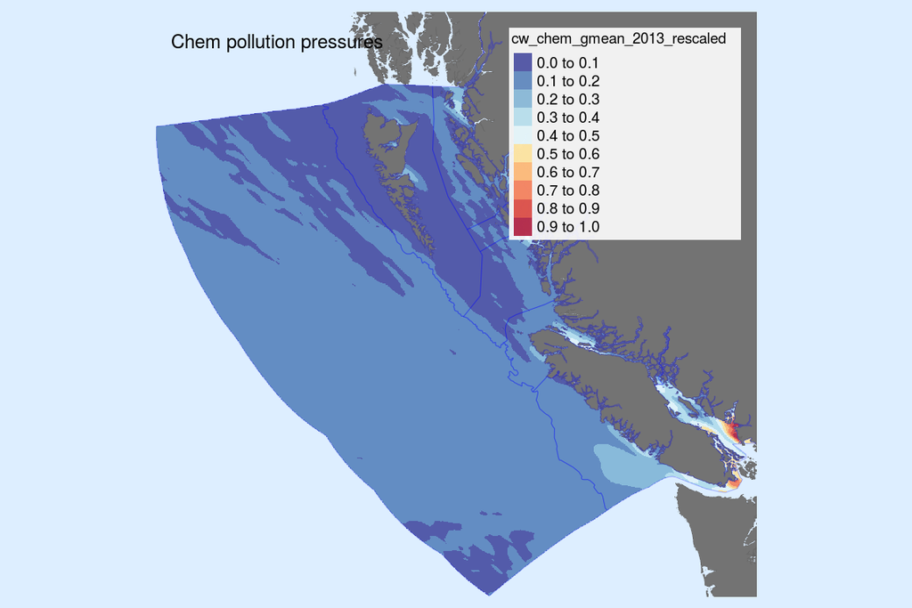

```r
### chemical: sum of rescaled inorganic (no TS) + ocean (no TS) + pesticides (2002-2013)

### 1. load regions
if(!exists('bc_rgn_poly'))
  bc_rgn_poly <- readOGR(dsn = path.expand(dir_spatial),
                         layer = 'ohibc_rgn')
if(!exists('bc_3nm_poly'))
  bc_3nm_poly <- readOGR(dsn = path.expand(dir_spatial),
                         layer = 'ohibc_offshore_3nm')

### 2. load layer(s)
chem_layer_files <- list.files(file.path(dir_goal_anx, 'rescaled_layers'),
                               pattern = '*chem_gmean*',
                               full.names = TRUE)
chem_stack <- stack(chem_layer_files) %>%
  setNames(chem_layer_files %>% basename %>% str_replace('.tif', '')) %>%
  raster::crop(bc_rgn_poly)

### NOTE:  The chem layers are sums of multiple sources of chemical pollution.
### These sums exceed 1.0; anything over 1 must be rescaled.
chem_stack_clipped <- chem_stack
values(chem_stack_clipped)[values(chem_stack_clipped) > 1] <- 1

years <- c(2002:2013)

reload <- FALSE

chem_scores_file <-  file.path(dir_goal, 'output', 'cw_chem_rgn_scores.csv')

if(!file.exists(chem_scores_file) | reload) {
  chem_list <- vector('list', length = length(years))
  for (i in 1:length(years)) {
    # i <- 1
    message('In loop; processing layer ', i, ' out of ', length(years))
    tmp_df <- rgn_extract(chem_stack_clipped[[i]], bc_3nm_poly)
    chem_list[[i]] <- tmp_df %>%
      rename(chem_val = cell_val) %>%
      mutate(year = years[i])
  }

  chem_df <- bind_rows(chem_list)

  # write_csv(chem_df, file.path(dir_goal, 'output', 'cw_chem_cells.csv'))

  chem_score_df <- chem_df %>%
    group_by(year, rgn_id) %>%
    summarize(chem_score = 1 - mean(chem_val, na.rm = TRUE))

  write_csv(chem_score_df, chem_scores_file)
}

chem_map <- plot_rast_map(chem_stack[[nlayers(chem_stack)]],
                          rgn_poly = bc_rgn_poly,
                          rev_scale = TRUE,
                          title = 'Chem pollution pressures')
```

## 3.3 Calculate trash scores

Trash scores are calculated across the entire EEZ. There is no time series for this layer.

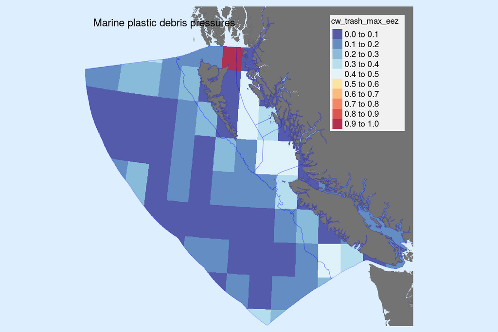

```r
### trash: rescaled marine plastics (no TS)

### 1. load regions
if(!exists('bc_rgn_poly'))
  bc_rgn_poly <- readOGR(dsn = path.expand(dir_spatial),
                         layer = 'ohibc_rgn')
if(!exists('bc_3nm_poly'))
  bc_3nm_poly <- readOGR(dsn = path.expand(dir_spatial),
                         layer = 'ohibc_offshore_3nm')

### 2. load layer(s)
trash_layer_files <- list.files(file.path(dir_goal, 'rescaled_layers'),
                               pattern = 'trash',
                               full.names = TRUE)

if(length(trash_layer_files) > 1) {
  message('More than one trash rescaled layer file! \n  ', paste(trash_layer_files, collapse = '\n  '))

  ### select max, linear scale, EEZ ref point
  quantile_tag <- str_detect(trash_layer_files, '_max_')
  region_tag   <- str_detect(trash_layer_files, '_eez')

  trash_layer_file <- trash_layer_files[quantile_tag & region_tag]
  message('Using: \n  ', trash_layer_file)
} else {
  trash_layer_file <- trash_layer_files[1]
}


trash_rast <- raster(trash_layer_file) %>%
  setNames(trash_layer_file %>%
             basename %>%
             str_replace('.tif', '')) %>%
  raster::crop(bc_rgn_poly)


reload <- TRUE

trash_scores_file <-  file.path(dir_goal, 'output', 'cw_trash_rgn_scores.csv')

if(!file.exists(trash_scores_file) | reload) {
  message('Calculating marine debris scores from ', names(trash_rast))
  trash_no_TS_df <- rgn_extract(trash_rast, bc_rgn_poly) %>%
    rename(trash_val = cell_val)

  # write_csv(trash_no_TS_df, file.path(dir_goal, 'output', 'cw_trash_cells.csv'))

  ### assemble a little dataframe to assign years to each region, even though values will all be the same...
  years <- c(2002:2013)
  rgns  <- unique(trash_no_TS_df$rgn_id)
  rgn_yrs <- data.frame(rgn_id = rep(rgns, times = length(years)),
                        year   = rep(years, each = length(rgns)))

  ### ... then bind that rgn/yr dataframe to expand out the trash score DF.
  trash_score_df <- trash_no_TS_df %>%
    group_by(rgn_id) %>%
    summarize(trash_score = 1 - mean(trash_val, na.rm = TRUE))

  trash_score_df <- trash_score_df %>%
    left_join(rgn_yrs, by = c('rgn_id'))

  write_csv(trash_score_df, trash_scores_file)
}

trash_map <- plot_rast_map(trash_rast,
                          rgn_poly = bc_rgn_poly,
                          rev_scale = TRUE,
                          title = 'Marine plastic debris pressures')
```

### 3.3.1 pathogens: still TBD

## 3.4 Calculate geometric mean of all scores.

```r
nutr_score_df  <- read_csv(file.path(dir_goal, 'output', 'cw_nutr_rgn_scores.csv'))
chem_score_df  <- read_csv(file.path(dir_goal, 'output', 'cw_chem_rgn_scores.csv'))
trash_score_df <- read_csv(file.path(dir_goal, 'output', 'cw_trash_rgn_scores.csv'))
# path_score_df <- read_csv(file.path(dir_goal, 'output', 'cw_path_rgn_scores.csv'))


cw_score_df <- nutr_score_df %>%
  full_join(chem_score_df, by = c('year', 'rgn_id')) %>%
  # full_join(path_score_df, by = c('year', 'rgn_id')) %>%
  full_join(trash_score_df, by = c('year', 'rgn_id'))

cw_score_summary <- cw_score_df %>%
  gather(source, value, nutr_score:trash_score) %>%
  group_by(year, rgn_id) %>%
  filter(!is.na(value)) %>%
  summarize(prod = prod(value),
            n_sources = n(),
            score = prod^(1/n_sources), ### this is our geometric mean
            sources = paste(source, collapse = ', '),
            values  = paste(round(value, 4), collapse = ', '))

write_csv(cw_score_summary, file.path(dir_goal, 'output', 'cw_score_summary.csv'))

DT::datatable(cw_score_summary)
```

|  | year | rgn_id | prod | n_sources | score | sources | values |
| --- | --- | --- | --- | --- | --- | --- | --- |
| 1 | 2002 | 1 | 0.586113376576419 | 3 | 0.836874903725182 | nutr_score, chem_score, trash_score | 0.9898, 0.8745, 0.6772 |
| 2 | 2002 | 2 | 0.685282012189239 | 3 | 0.881636937737151 | nutr_score, chem_score, trash_score | 0.9957, 0.9243, 0.7446 |
| 3 | 2002 | 3 | 0.57242626037994 | 3 | 0.830309199349604 | nutr_score, chem_score, trash_score | 0.9874, 0.8788, 0.6597 |
| 4 | 2002 | 4 | 0.628220600656018 | 3 | 0.856454031276205 | nutr_score, chem_score, trash_score | 0.9847, 0.845, 0.755 |
| 5 | 2002 | 5 | 0.561919035639439 | 3 | 0.825197521430211 | nutr_score, chem_score, trash_score | 0.9599, 0.7732, 0.757 |
| 6 | 2002 | 6 | 0.502853063340883 | 3 | 0.795207315546749 | nutr_score, chem_score, trash_score | 0.9193, 0.6607, 0.8279 |
| 7 | 2002 | 7 | 0.881548277122688 | 1 | 0.881548277122688 | trash_score | 0.8815 |
| 8 | 2002 | 8 | 0.627465007170666 | 3 | 0.856110526300726 | nutr_score, chem_score, trash_score | 0.9979, 0.9059, 0.6941 |
| 9 | 2003 | 1 | 0.586337143173358 | 3 | 0.836981390985431 | nutr_score, chem_score, trash_score | 0.9902, 0.8745, 0.6772 |
| 10 | 2003 | 2 | 0.685603108013971 | 3 | 0.881774616206852 | nutr_score, chem_score, trash_score | 0.9962, 0.9243, 0.7446 |

[output cut: 86 more lines]

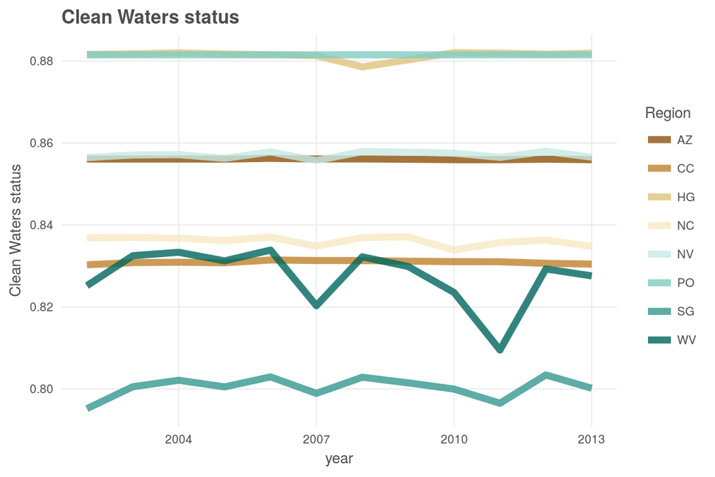

```r
cw_score_summary <- read_csv(file.path(dir_goal, 'output', 'cw_score_summary.csv'))

bc_rgn_info <- foreign::read.dbf(file.path(dir_spatial, 'ohibc_rgn.dbf'))

st_trend_ts_plot <- ggplot(cw_score_summary %>%
                             full_join(bc_rgn_info, by = 'rgn_id'),
                           aes(x = year, y = score, color = rgn_code, group = rgn_code)) +
  ggtheme_plot() +
  geom_line(size = 2, alpha = .8) +
  scale_colour_brewer(palette = 'BrBG') +
  labs(x = 'year',
       y = 'Clean Waters status',
       title = 'Clean Waters status',
       color = 'Region')

print(st_trend_ts_plot)
```

```r
prov_wrapup()
```

# 4 Provenance

- *Run ID: 1 (0b719c9); run tag: “standard run”*
- *Run elapsed time: 230.839 seconds; run memory usage: 30311.2 MB*
- *System info:*
  - *System: Linux, Release: 4.4.0-57-generic. Machine: x86_64. User: ohara.*
  - *R version: R version 3.3.3 (2017-03-06), Platform: x86_64-pc-linux-gnu, Running under: Ubuntu 14.04.5 LTS.*
  - *Attached base packages: stats, graphics, grDevices, utils, datasets, methods, base*
  - *Other attached packages: maptools_0.8-39, tmap_1.6-1, provRmd_0.1.1, stringr_1.2.0, RColorBrewer_1.1-2, dplyr_0.5.0, purrr_0.2.2, readr_1.1.0, tidyr_0.6.1, tibble_1.3.0, ggplot2_2.2.1, tidyverse_1.0.0, here_0.0-5, raster_2.5-8, rgdal_1.2-5, sp_1.2-4*

[figure not shown]

| sequence | file_name | parent_chunk | file_dir | filetype | uncomm_chgs | commit_hash_short |
| --- | --- | --- | --- | --- | --- | --- |
| 0 | cw_goal_prep.rmd | prov_footer | ~/github/ohibc/prep/cw/v2017 | parent_script | True | c91d889 |
| 0 | cw_goal_prep.rmd#calc_chem_scores | calc_chem_scores | ~/github/ohibc/prep/cw/v2017 | parent_chunk | True | c91d889 |
| 0 | cw_goal_prep.rmd#calc_geom_means | calc_geom_means | ~/github/ohibc/prep/cw/v2017 | parent_chunk | True | c91d889 |
| 0 | cw_goal_prep.rmd#calc_nutrient_scores | calc_nutrient_scores | ~/github/ohibc/prep/cw/v2017 | parent_chunk | True | c91d889 |
| 0 | cw_goal_prep.rmd#calc_trash_scores | calc_trash_scores | ~/github/ohibc/prep/cw/v2017 | parent_chunk | True | c91d889 |
| 0 | cw_goal_prep.rmd#make_a_pretty_plot | make_a_pretty_plot | ~/github/ohibc/prep/cw/v2017 | parent_chunk | True | c91d889 |
| 0 | cw_goal_prep.rmd#prov_footer | prov_footer | ~/github/ohibc/prep/cw/v2017 | parent_chunk | True | c91d889 |
| 0 | cw_goal_prep.rmd#setup | setup | ~/github/ohibc/prep/cw/v2017 | parent_chunk | True | c91d889 |
| 1 | map_scores.R | setup | ~/github/ohibc/src/R | sourced_script | False | 9eddda8 |
| 2 | rast_tools.R | setup | ~/github/ohibc/src/R | sourced_script | False | eb9de8a |

[output cut: 33 more lines]